# ps05-rmarkdown-plot

Karishma Raj

2023-02-18

# 1. Load and check data

```r
gapminder <- read.delim("/Users/karishmaraj/Downloads/gapminder.csv.bz2")
rows <- nrow(gapminder)
cols <- ncol(gapminder)
```

There are 13055 rows and 25 columns.

```r
head(gapminder)
```

```
##   iso3  name iso2   region                      sub.region intermediate.region
## 1  ABW Aruba   AW Americas Latin America and the Caribbean           Caribbean
## 2  ABW Aruba   AW Americas Latin America and the Caribbean           Caribbean
## 3  ABW Aruba   AW Americas Latin America and the Caribbean           Caribbean
## 4  ABW Aruba   AW Americas Latin America and the Caribbean           Caribbean
## 5  ABW Aruba   AW Americas Latin America and the Caribbean           Caribbean
## 6  ABW Aruba   AW Americas Latin America and the Caribbean           Caribbean
##   time totalPopulation fertilityRate lifeExpectancy childMortality
## 1 1960           54211         4.820         65.662             NA
## 2 1961           55438         4.655         66.074             NA
## 3 1962           56225         4.471         66.444             NA
## 4 1963           56695         4.271         66.787             NA
## 5 1964           57032         4.059         67.113             NA
## 6 1965           57360         3.842         67.435             NA
##   youthFemaleLiteracy youthMaleLiteracy adultLiteracy GDP_PC accessElectricity
```

[output cut: 20 more lines]

# 2. Descriptive statistics

```r
countries_iso3 <- length(unique(gapminder$iso3))
countries_iso2 <- length(unique(gapminder$iso2))
countries_name <- length(unique(gapminder$name))
```

There are 253 iso3 countries, 249 iso2 countries, and 250 country names.

```r
library(dplyr)
gapminder %>%
  group_by(iso2) %>%
  summarize(num_names = n()) %>%
  filter(num_names > 1)
```

```
## # A tibble: 213 × 2
##    iso2  num_names
##    <chr>     <int>
##  1 ""          300
##  2 "AD"         60
##  3 "AE"         60
##  4 "AF"         60
##  5 "AG"         60
##  6 "AL"         60
##  7 "AM"         60
##  8 "AO"         60
##  9 "AR"         60
## 10 "AS"         60
## # … with 203 more rows
```

```r
gapminder %>%
  group_by(iso2) %>%
  summarize(num = n_distinct(name)) %>%
  arrange(desc(num))
```

```
## # A tibble: 249 × 2
##    iso2    num
##    <chr> <int>
##  1 ""        2
##  2 "AD"      1
##  3 "AE"      1
##  4 "AF"      1
##  5 "AG"      1
##  6 "AI"      1
##  7 "AL"      1
##  8 "AM"      1
##  9 "AO"      1
## 10 "AQ"      1
## # … with 239 more rows
```

```r
gapminder %>%
  group_by(iso3) %>%
  summarize(num_names = n()) %>%
  filter(num_names > 1)
```

```
## # A tibble: 217 × 2
##    iso3  num_names
##    <chr>     <int>
##  1 ABW          60
##  2 AFG          60
##  3 AGO          60
##  4 ALB          60
##  5 AND          60
##  6 ARE          60
##  7 ARG          60
##  8 ARM          60
##  9 ASM          60
## 10 ATG          60
## # … with 207 more rows
```

```r
gapminder %>%
  group_by(iso3) %>%
  summarize(num = n_distinct(name)) %>%
  arrange(desc(num))
```

```
## # A tibble: 253 × 2
##    iso3    num
##    <chr> <int>
##  1 ABW       1
##  2 AFG       1
##  3 AGO       1
##  4 AIA       1
##  5 ALA       1
##  6 ALB       1
##  7 AND       1
##  8 ARE       1
##  9 ARG       1
## 10 ARM       1
## # … with 243 more rows
```

CHANSIL, NLD CURACAO, GBM, AND KOS have more than one iso3 code.

```r
max_year <- max(gapminder$time, na.ram = TRUE)
min_year <- min(gapminder$time, na.ram = TRUE)
```

2019 is the maximum year and 1960 is the minimum year.

# 3. CO2 emissions

```r
missing_CO2 <- tapply(is.na(gapminder$co2), gapminder$time, sum)
missing_CO2
```

```
## 1960 1961 1962 1963 1964 1965 1966 1967 1968 1969 1970 1971 1972 1973 1974 1975
##   60   60   58   57   51   51   51   51   51   51   50   49   48   48   48   48
## 1976 1977 1978 1979 1980 1981 1982 1983 1984 1985 1986 1987 1988 1989 1990 1991
##   48   48   48   48   48   48   48   48   48   48   48   48   48   48   41   40
## 1992 1993 1994 1995 1996 1997 1998 1999 2000 2001 2002 2003 2004 2005 2006 2007
##   19   19   18   18   18   18   18   18   18   18   17   17   17   16   15   14
## 2008 2009 2010 2011 2012 2013 2014 2015 2016 2017 2018 2019
##   13   13   13   13   10   10   10   13   13  217  217  217
```

```r
sort_CO2 <- sort(desc(missing_CO2))
missing_CO2_PC <- tapply(is.na(gapminder$co2_PC), gapminder$time, sum)
missing_CO2_PC
```

```
## 1960 1961 1962 1963 1964 1965 1966 1967 1968 1969 1970 1971 1972 1973 1974 1975
##   60   60   58   57   51   51   51   51   51   51   50   49   48   48   48   48
## 1976 1977 1978 1979 1980 1981 1982 1983 1984 1985 1986 1987 1988 1989 1990 1991
##   48   48   48   48   48   48   48   48   48   48   48   48   48   48   41   40
## 1992 1993 1994 1995 1996 1997 1998 1999 2000 2001 2002 2003 2004 2005 2006 2007
##   20   20   19   18   18   18   18   18   18   18   17   17   17   16   15   14
## 2008 2009 2010 2011 2012 2013 2014 2015 2016 2017 2018 2019
##   13   13   13   13   10   10   10   13   13  217  217  217
```

```r
sort_CO2_PC <- sort(desc(missing_CO2_PC))
sort_CO2_PC
```

```
## 2017 2018 2019 1960 1961 1962 1963 1964 1965 1966 1967 1968 1969 1970 1971 1972
## -217 -217 -217  -60  -60  -58  -57  -51  -51  -51  -51  -51  -51  -50  -49  -48
## 1973 1974 1975 1976 1977 1978 1979 1980 1981 1982 1983 1984 1985 1986 1987 1988
##  -48  -48  -48  -48  -48  -48  -48  -48  -48  -48  -48  -48  -48  -48  -48  -48
## 1989 1990 1991 1992 1993 1994 1995 1996 1997 1998 1999 2000 2001 2002 2003 2004
##  -48  -41  -40  -20  -20  -19  -18  -18  -18  -18  -18  -18  -18  -17  -17  -17
## 2005 2006 2007 2008 2009 2010 2011 2015 2016 2012 2013 2014
##  -16  -15  -14  -13  -13  -13  -13  -13  -13  -10  -10  -10
```

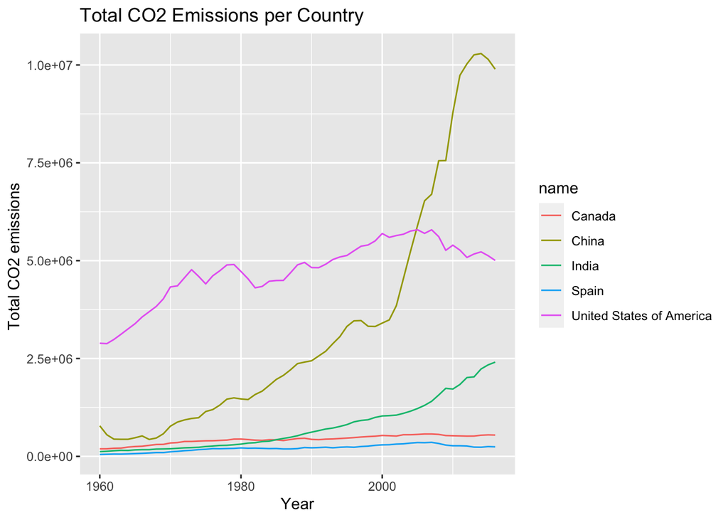

```r
library(ggplot2)
gapminder2 <- subset(gapminder, name %in% c("United States of America", "China", "India", "Canada", "Spain"))
total_co2 <- aggregate(co2 ~ time + name, gapminder2, sum)
ggplot(total_co2, aes(x = time, y = co2, color = name)) +
  geom_line() +
  labs(x = "Year", y = "Total CO2 emissions ",
       title = "Total CO2 Emissions per Country")
```

In comparison to other countries, China seems to have the highest increase in CO2 emissions. India, Canada, and Spain have very low rates of CO2 emissions compared to China and the USA.

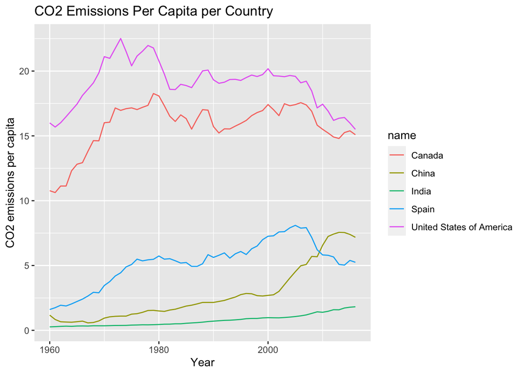

```r
gapminder3 <- subset(gapminder, name %in% c("United States of America", "China", "India", "Canada", "Spain"))
co2_pc <- aggregate(co2_PC ~ time + name, gapminder3, sum)
ggplot(co2_pc, aes(x = time, y = co2_PC, color = name)) +
  geom_line() +
  labs(x = "Year", y = "CO2 emissions per capita",
       title = "CO2 Emissions Per Capita per Country")
```

The USA has consistently had the highest CO2 emissions per capita with Canada having a similar but lower rate. The other countries had much lower CO2 emissions per capita.

```r
CO2_pc_by_continent <- gapminder %>%
  group_by(region) %>%
  filter(time == 2016) %>%
  summarise(mean_CO2_PC = mean(co2_PC, na.rm = TRUE)) %>%
  select(region, mean_CO2_PC)

CO2_pc_by_continent
```

```
## # A tibble: 6 × 2
##   region     mean_CO2_PC
##   <chr>            <dbl>
## 1 ""               19.4
## 2 "Africa"          1.20
## 3 "Americas"        4.80
## 4 "Asia"            6.47
## 5 "Europe"          6.64
## 6 "Oceania"         4.57
```

In 2016, Europe had the highest mean CO2 per capita. Africa had the lowest mean CO2 emissions per capita.

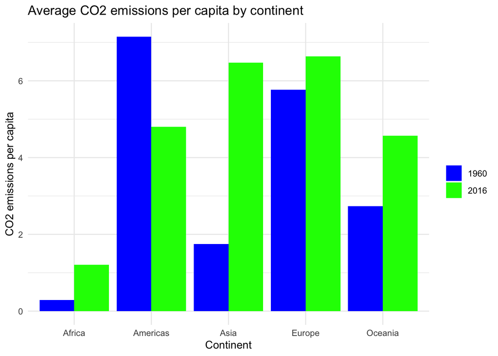

```r
library(tidyr)

CO2_pc_by_continent_1960 <- aggregate(co2_PC ~ region, gapminder[gapminder$time == 1960, ], mean)
CO2_pc_by_continent_2016 <- aggregate(co2_PC ~ region, gapminder[gapminder$time == 2016, ], mean)
CO2_pc_by_continent <- merge(CO2_pc_by_continent_1960, CO2_pc_by_continent_2016, by = "region")
colnames(CO2_pc_by_continent) <- c("continent", "1960", "2016")
CO2_pc_by_continent_long <- gather(CO2_pc_by_continent, key = "variable", value = "value", -continent)
ggplot(CO2_pc_by_continent_long, aes(x = continent, y = value, fill = variable)) +
  geom_bar(stat = "identity", position = "dodge") +
  labs(x = "Continent", y = "CO2 emissions per capita", fill = "") +
  ggtitle("Average CO2 emissions per capita by continent") +
  scale_fill_manual(values = c("1960" = "blue", "2016" = "green")) +
  theme_minimal()
```

```r
gapminder_2019 <- gapminder %>%
  filter(time == 2019)
top_bottom_CO2 <- gapminder_2019 %>%
  group_by(region) %>%
  arrange(co2_PC) %>%
  summarise(top_3 = paste(name[1:3], collapse = ", "),
            bottom_3 = paste(name[(n() - 2):n()], collapse = ", "))
top_bottom_CO2
```

```
## # A tibble: 6 × 3
##   region     top_3                                        bottom_3
##   <chr>      <chr>                                        <chr>
## 1 ""         ", , "                                       ", , "
## 2 "Africa"   "Angola, Burundi, Benin"                     "South Africa, Zambia…
## 3 "Americas" "Aruba, Argentina, Antigua and Barbuda"      "Venezuela (Bolivaria…
## 4 "Asia"     "Afghanistan, United Arab Emirates, Armenia" "Uzbekistan, Viet Nam…
## 5 "Europe"   "Albania, Andorra, Austria"                  "Slovenia, Sweden, Uk…
## 6 "Oceania"  "American Samoa, Australia, Fiji"            "Tuvalu, Vanuatu, Sam…
```

# 4. GDP per capita

[figure not shown]

```r
gapminder_1960 <- gapminder[gapminder$year == 1960,]
continent_colors <- c("Asia" = "blue", "Africa" = "green", "Europe" = "purple",
                      "Americas" = "red", "Oceania" = "orange")

ggplot(gapminder_1960, aes(x = GDP_PC, y = lifeExpectancy, size = totalPopulation, color = region)) +
  geom_point(alpha = 0.7) +
  scale_size_continuous(range = c(2, 10)) +
  scale_color_manual(values = continent_colors) +
  labs(title = "GDP per Capita vs Life Expectancy by Country (1960)",
       x = "GDP per Capita", y = "Life Expectancy",
       size = "Population", color = "Continent") +
  theme_minimal()
```

[figure not shown]

```r
gapminder_1960 <- gapminder[gapminder$year == 2019,]
continent_colors <- c("Asia" = "blue", "Africa" = "green", "Europe" = "purple",
                      "Americas" = "red", "Oceania" = "orange")

ggplot(gapminder_1960, aes(x = GDP_PC, y = lifeExpectancy, size = totalPopulation, color = region)) +
  geom_point(alpha = 0.7) +
  scale_size_continuous(range = c(2, 10)) +
  scale_color_manual(values = continent_colors) +
  labs(title = "GDP per Capita vs Life Expectancy by Country (1960)",
       x = "GDP per Capita", y = "Life Expectancy",
       size = "Population", color = "Continent") +
  theme_minimal()
```

```r
life_exp <- gapminder %>%
  filter(time %in% c(1960, 2019)) %>%
  group_by(region, time) %>%
  summarise(mean_life_exp = mean(lifeExpectancy, na.rm = TRUE))
life_exp
```

```
## # A tibble: 12 × 3
## # Groups:   region [6]
##    region      time mean_life_exp
##    <chr>      <int>         <dbl>
##  1 ""          1960          70.7
##  2 ""          2019          77.8
##  3 "Africa"    1960          41.5
##  4 "Africa"    2019          64.1
##  5 "Americas"  1960          58.6
##  6 "Americas"  2019          75.8
##  7 "Asia"      1960          51.6
##  8 "Asia"      2019          74.6
##  9 "Europe"    1960          68.3
## 10 "Europe"    2019          79.4
## 11 "Oceania"   1960          56.4
## 12 "Oceania"   2019          73.5
```

Yes, the results do seem to fit with the figures.

```r
LE_growth <- gapminder %>%
  filter(time %in% c(1960, 2019)) %>%
  group_by(region) %>%
  mutate(growth_rate = (lifeExpectancy - lag(lifeExpectancy)) / lag(lifeExpectancy)) %>%
  summarise(avg_growth = mean(growth_rate, na.rm = TRUE)) %>%
  arrange(desc(avg_growth))

LE_growth
```

```
## # A tibble: 6 × 2
##   region     avg_growth
##   <chr>           <dbl>
## 1 ""             0.175
## 2 "Oceania"      0.113
## 3 "Africa"       0.112
## 4 "Asia"         0.0987
## 5 "Americas"     0.0656
## 6 "Europe"       0.0209
```

Oceana has the highest life expectancy growth rate, while Europe has the lowest life expectancy growth rate.

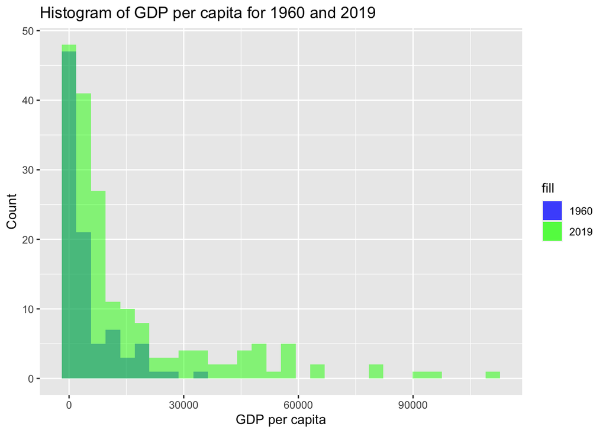

```r
gapminder_1960_2019 <- gapminder %>% filter(time %in% c(1960, 2019))
ggplot(data = gapminder_1960_2019, aes(x = GDP_PC)) +
  geom_histogram(data = filter(gapminder_1960_2019, time == 1960), aes(fill = "1960"), alpha = 0.5, bins = 30) +
  geom_histogram(data = filter(gapminder_1960_2019, time == 2019), aes(fill = "2019"), alpha = 0.5, bins = 30) +
  scale_fill_manual(values = c("1960" = "blue", "2019" = "green")) +
  ggtitle("Histogram of GDP per capita for 1960 and 2019") +
  xlab("GDP per capita") + ylab("Count")
```

```r
LE_1960_2019 <- gapminder %>% filter(time %in% c(1960, 2019))
LE_rank_1960 <- LE_1960_2019 %>%
  filter(time == 1960) %>%
  mutate(rank = rank(desc(lifeExpectancy))) %>%
  filter(name == "United States of America") %>%
  pull(rank)

LE_rank_2019 <- LE_1960_2019 %>%
  filter(time == 2019) %>%
  mutate(rank = rank(desc(lifeExpectancy))) %>%
  filter(name == "United States of America") %>%
  pull(rank)

cat("Life expectancy ranking of the US in 1960:", LE_rank_1960, " ")
```

```
## Life expectancy ranking of the US in 1960: 18
```

```r
cat("Life expectancy ranking of the US in 2019:", LE_rank_2019, " ")
```

```
## Life expectancy ranking of the US in 2019: 47
```

```r
num_countries_1960 <- gapminder %>%
  filter(time == 1960) %>%
  distinct(name) %>%
  nrow()

num_countries_2019 <- gapminder %>%
  filter(time == 2019) %>%
  distinct(name) %>%
  nrow()

us_rank_1960 <- gapminder %>%
  filter(time == 1960) %>%
  arrange(desc(lifeExpectancy)) %>%
  mutate(rank = row_number()) %>%
  filter(name == "United States of America") %>%
  select(rank) %>%
  pull()

relative_rank_1960 <- LE_rank_1960 / num_countries_1960

us_rank_2019 <- gapminder %>%
  filter(time == 2019) %>%
  arrange(desc(lifeExpectancy)) %>%
  mutate(rank = row_number()) %>%
  filter(name == "United States of America") %>%
  select(rank) %>%
  pull()

relative_rank_2019 <- LE_rank_2019 / num_countries_2019

cat("Relative life expectancy rank of US in 1960:", relative_rank_1960, " ")
```

```
## Relative life expectancy rank of US in 1960: 0.08450704
```